# 12,13,14일차

```python
# 출처: https://community.ibm.com/accelerators/

import pandas as pd

df = pd.read_csv('test3.csv')
print(df.shape)
df.head().T
```

```
(7043, 21)
```

|  | 0 | 1 | 2 | 3 | 4 |
| --- | --- | --- | --- | --- | --- |
| customerID | 7590-VHVEG | 5575-GNVDE | 3668-QPYBK | 7795-CFOCW | 9237-HQITU |
| gender | Female | Male | Male | Male | Female |
| SeniorCitizen | 0 | 0 | 0 | 0 | 0 |
| Partner | Yes | No | No | No | No |
| Dependents | No | No | No | No | No |
| tenure | 1 | 34 | 2 | 45 | 2 |
| PhoneService | No | Yes | Yes | No | Yes |
| MultipleLines | No phone service | No | No | No phone service | No |
| InternetService | DSL | DSL | DSL | DSL | Fiber optic |
| OnlineSecurity | No | Yes | Yes | Yes | No |
| OnlineBackup | Yes | No | Yes | No | No |
| DeviceProtection | No | Yes | No | Yes | No |
| TechSupport | No | No | No | Yes | No |
| StreamingTV | No | No | No | No | No |
| StreamingMovies | No | No | No | No | No |
| Contract | Month-to-month | One year | Month-to-month | One year | Month-to-month |
| PaperlessBilling | Yes | No | Yes | No | Yes |
| PaymentMethod | Electronic check | Mailed check | Mailed check | Bank transfer (automatic) | Electronic check |
| MonthlyCharges | 29.85 | 56.95 | 53.85 | 42.3 | 70.7 |
| TotalCharges | 29.85 | 1889.5 | 108.15 | 1840.75 | 151.65 |
| Churn | No | No | Yes | No | Yes |

## Business Understanding

- 통신사 고객 관리
- 통신사는 고객과의 약정을 통해 정기적인 현금 흐름을 만들어냄
- 고객의 인원수가 중요
- 고객 이탈과 가장 관련있는 요인이 무엇일까?

## Data Understanding

```python
df.columns
```

```
Index(['customerID', 'gender', 'SeniorCitizen', 'Partner', 'Dependents',
       'tenure', 'PhoneService', 'MultipleLines', 'InternetService',
       'OnlineSecurity', 'OnlineBackup', 'DeviceProtection', 'TechSupport',
       'StreamingTV', 'StreamingMovies', 'Contract', 'PaperlessBilling',
       'PaymentMethod', 'MonthlyCharges', 'TotalCharges', 'Churn'],
      dtype='object')
```

```python
len(set(df['customerID']))
```

```
7043
```

```python
set(df['InternetService'])
```

```
{'DSL', 'Fiber optic', 'No'}
```

```python
df.describe()
```

|  | SeniorCitizen | tenure | MonthlyCharges |
| --- | --- | --- | --- |
| count | 7043.000000 | 7043.000000 | 7043.000000 |
| mean | 0.162147 | 32.371149 | 64.761692 |
| std | 0.368612 | 24.559481 | 30.090047 |
| min | 0.000000 | 0.000000 | 18.250000 |
| 25% | 0.000000 | 9.000000 | 35.500000 |
| 50% | 0.000000 | 29.000000 | 70.350000 |
| 75% | 0.000000 | 55.000000 | 89.850000 |
| max | 1.000000 | 72.000000 | 118.750000 |

```python
df.sort_values(by='TotalCharges')['TotalCharges']
```

```
936
3826
4380
753
5218
         ...
6646    997.75
5598     998.1
3686    999.45
3353     999.8
2845     999.9
Name: TotalCharges, Length: 7043, dtype: object
```

```python
df.sort_values(by='TotalCharges')['TotalCharges'][936]

# 띄어쓰기 한 칸으로 표기된 데이터 존재
```

```
' '
```

#### 빈 값 처리 방법

1. 그냥 지우기
2. 도메인 지식
3. 평균 대체법
4. 해당 column을 label로 두고, ML이 학습해서 predict로 빈 값을 채워넣기

```python
df.loc[df['TotalCharges'] == ' ']

# 빈 값을 처리하기 위해서 대표성이 있는 column을 찾아 채워넣어야 함
```

|  | customerID | gender | SeniorCitizen | Partner | Dependents | tenure | PhoneService | MultipleLines | InternetService | OnlineSecurity | ... | DeviceProtection | TechSupport | StreamingTV | StreamingMovies | Contract | PaperlessBilling | PaymentMethod | MonthlyCharges | TotalCharges | Churn |
| --- | --- | --- | --- | --- | --- | --- | --- | --- | --- | --- | --- | --- | --- | --- | --- | --- | --- | --- | --- | --- | --- |
| 488 | 4472-LVYGI | Female | 0 | Yes | Yes | 0 | No | No phone service | DSL | Yes | ... | Yes | Yes | Yes | No | Two year | Yes | Bank transfer (automatic) | 52.55 |  | No |
| 753 | 3115-CZMZD | Male | 0 | No | Yes | 0 | Yes | No | No | No internet service | ... | No internet service | No internet service | No internet service | No internet service | Two year | No | Mailed check | 20.25 |  | No |
| 936 | 5709-LVOEQ | Female | 0 | Yes | Yes | 0 | Yes | No | DSL | Yes | ... | Yes | No | Yes | Yes | Two year | No | Mailed check | 80.85 |  | No |
| 1082 | 4367-NUYAO | Male | 0 | Yes | Yes | 0 | Yes | Yes | No | No internet service | ... | No internet service | No internet service | No internet service | No internet service | Two year | No | Mailed check | 25.75 |  | No |
| 1340 | 1371-DWPAZ | Female | 0 | Yes | Yes | 0 | No | No phone service | DSL | Yes | ... | Yes | Yes | Yes | No | Two year | No | Credit card (automatic) | 56.05 |  | No |
| 3331 | 7644-OMVMY | Male | 0 | Yes | Yes | 0 | Yes | No | No | No internet service | ... | No internet service | No internet service | No internet service | No internet service | Two year | No | Mailed check | 19.85 |  | No |
| 3826 | 3213-VVOLG | Male | 0 | Yes | Yes | 0 | Yes | Yes | No | No internet service | ... | No internet service | No internet service | No internet service | No internet service | Two year | No | Mailed check | 25.35 |  | No |
| 4380 | 2520-SGTTA | Female | 0 | Yes | Yes | 0 | Yes | No | No | No internet service | ... | No internet service | No internet service | No internet service | No internet service | Two year | No | Mailed check | 20.00 |  | No |
| 5218 | 2923-ARZLG | Male | 0 | Yes | Yes | 0 | Yes | No | No | No internet service | ... | No internet service | No internet service | No internet service | No internet service | One year | Yes | Mailed check | 19.70 |  | No |
| 6670 | 4075-WKNIU | Female | 0 | Yes | Yes | 0 | Yes | Yes | DSL | No | ... | Yes | Yes | Yes | No | Two year | No | Mailed check | 73.35 |  | No |
| 6754 | 2775-SEFEE | Male | 0 | No | Yes | 0 | Yes | Yes | DSL | Yes | ... | No | Yes | No | No | Two year | Yes | Bank transfer (automatic) | 61.90 |  | No |

11 rows × 21 columns

```python
# Q) SeniorCitizen은 대표성이 있는가?
# A) 대표성이 없음
```

```python
# Q) Dependents는 대표성이 있나요?
df.loc[df['Dependents'] == 'Yes']
# X
```

|  | customerID | gender | SeniorCitizen | Partner | Dependents | tenure | PhoneService | MultipleLines | InternetService | OnlineSecurity | ... | DeviceProtection | TechSupport | StreamingTV | StreamingMovies | Contract | PaperlessBilling | PaymentMethod | MonthlyCharges | TotalCharges | Churn |
| --- | --- | --- | --- | --- | --- | --- | --- | --- | --- | --- | --- | --- | --- | --- | --- | --- | --- | --- | --- | --- | --- |
| 6 | 1452-KIOVK | Male | 0 | No | Yes | 22 | Yes | Yes | Fiber optic | No | ... | No | No | Yes | No | Month-to-month | Yes | Credit card (automatic) | 89.10 | 1949.4 | No |
| 9 | 6388-TABGU | Male | 0 | No | Yes | 62 | Yes | No | DSL | Yes | ... | No | No | No | No | One year | No | Bank transfer (automatic) | 56.15 | 3487.95 | No |
| 10 | 9763-GRSKD | Male | 0 | Yes | Yes | 13 | Yes | No | DSL | Yes | ... | No | No | No | No | Month-to-month | Yes | Mailed check | 49.95 | 587.45 | No |
| 15 | 3655-SNQYZ | Female | 0 | Yes | Yes | 69 | Yes | Yes | Fiber optic | Yes | ... | Yes | Yes | Yes | Yes | Two year | No | Credit card (automatic) | 113.25 | 7895.15 | No |
| 17 | 9959-WOFKT | Male | 0 | No | Yes | 71 | Yes | Yes | Fiber optic | Yes | ... | Yes | No | Yes | Yes | Two year | No | Bank transfer (automatic) | 106.70 | 7382.25 | No |
| ... | ... | ... | ... | ... | ... | ... | ... | ... | ... | ... | ... | ... | ... | ... | ... | ... | ... | ... | ... | ... | ... |
| 7018 | 1122-JWTJW | Male | 0 | Yes | Yes | 1 | Yes | No | Fiber optic | No | ... | No | No | No | No | Month-to-month | Yes | Mailed check | 70.65 | 70.65 | Yes |
| 7020 | 9837-FWLCH | Male | 0 | Yes | Yes | 12 | Yes | No | No | No internet service | ... | No internet service | No internet service | No internet service | No internet service | Month-to-month | Yes | Electronic check | 19.20 | 239 | No |
| 7038 | 6840-RESVB | Male | 0 | Yes | Yes | 24 | Yes | Yes | DSL | Yes | ... | Yes | Yes | Yes | Yes | One year | Yes | Mailed check | 84.80 | 1990.5 | No |
| 7039 | 2234-XADUH | Female | 0 | Yes | Yes | 72 | Yes | Yes | Fiber optic | No | ... | Yes | No | Yes | Yes | One year | Yes | Credit card (automatic) | 103.20 | 7362.9 | No |
| 7040 | 4801-JZAZL | Female | 0 | Yes | Yes | 11 | No | No phone service | DSL | Yes | ... | No | No | No | No | Month-to-month | Yes | Electronic check | 29.60 | 346.45 | No |

2110 rows × 21 columns

```python
# Q) tenure는 대표성이 있나요?
df.loc[df['tenure'] == 0]

# 서비스 이용 기간이 1개월 미만인 고객은 총 청구금액이 없다.
# tenure는 대표성이 있다.
```

|  | customerID | gender | SeniorCitizen | Partner | Dependents | tenure | PhoneService | MultipleLines | InternetService | OnlineSecurity | ... | DeviceProtection | TechSupport | StreamingTV | StreamingMovies | Contract | PaperlessBilling | PaymentMethod | MonthlyCharges | TotalCharges | Churn |
| --- | --- | --- | --- | --- | --- | --- | --- | --- | --- | --- | --- | --- | --- | --- | --- | --- | --- | --- | --- | --- | --- |
| 488 | 4472-LVYGI | Female | 0 | Yes | Yes | 0 | No | No phone service | DSL | Yes | ... | Yes | Yes | Yes | No | Two year | Yes | Bank transfer (automatic) | 52.55 |  | No |
| 753 | 3115-CZMZD | Male | 0 | No | Yes | 0 | Yes | No | No | No internet service | ... | No internet service | No internet service | No internet service | No internet service | Two year | No | Mailed check | 20.25 |  | No |
| 936 | 5709-LVOEQ | Female | 0 | Yes | Yes | 0 | Yes | No | DSL | Yes | ... | Yes | No | Yes | Yes | Two year | No | Mailed check | 80.85 |  | No |
| 1082 | 4367-NUYAO | Male | 0 | Yes | Yes | 0 | Yes | Yes | No | No internet service | ... | No internet service | No internet service | No internet service | No internet service | Two year | No | Mailed check | 25.75 |  | No |
| 1340 | 1371-DWPAZ | Female | 0 | Yes | Yes | 0 | No | No phone service | DSL | Yes | ... | Yes | Yes | Yes | No | Two year | No | Credit card (automatic) | 56.05 |  | No |
| 3331 | 7644-OMVMY | Male | 0 | Yes | Yes | 0 | Yes | No | No | No internet service | ... | No internet service | No internet service | No internet service | No internet service | Two year | No | Mailed check | 19.85 |  | No |
| 3826 | 3213-VVOLG | Male | 0 | Yes | Yes | 0 | Yes | Yes | No | No internet service | ... | No internet service | No internet service | No internet service | No internet service | Two year | No | Mailed check | 25.35 |  | No |
| 4380 | 2520-SGTTA | Female | 0 | Yes | Yes | 0 | Yes | No | No | No internet service | ... | No internet service | No internet service | No internet service | No internet service | Two year | No | Mailed check | 20.00 |  | No |
| 5218 | 2923-ARZLG | Male | 0 | Yes | Yes | 0 | Yes | No | No | No internet service | ... | No internet service | No internet service | No internet service | No internet service | One year | Yes | Mailed check | 19.70 |  | No |
| 6670 | 4075-WKNIU | Female | 0 | Yes | Yes | 0 | Yes | Yes | DSL | No | ... | Yes | Yes | Yes | No | Two year | No | Mailed check | 73.35 |  | No |
| 6754 | 2775-SEFEE | Male | 0 | No | Yes | 0 | Yes | Yes | DSL | Yes | ... | No | Yes | No | No | Two year | Yes | Bank transfer (automatic) | 61.90 |  | No |

11 rows × 21 columns

```python
tc_null = set(df.loc[df['TotalCharges'] == ' ']['customerID'].values)
```

```python
te_null = set(df.loc[df['tenure'] == 0]['customerID'].values)
```

```python
print(len(tc_null.difference(te_null)))
print(len(te_null.difference(tc_null)))

# tenure이 0인 row와 TotalCharges가 빈 칸인 row는 정확히 같음
# 즉, 계약하고 1개월 미만인 고객들은 총 납부 금액 모두 빈 칸으로 되어 있음 ->
# TotalCharges가 빈 칸인 row는 모두 0으로 저장할 수 있음
```

```
0
0
```

```python
df.loc[df['tenure'] == 0, 'TotalCharges'] = 0

df['TotalCharges'] = df['TotalCharges'].apply(lambda x : float(x))
df.describe()
```

|  | SeniorCitizen | tenure | MonthlyCharges | TotalCharges |
| --- | --- | --- | --- | --- |
| count | 7043.000000 | 7043.000000 | 7043.000000 | 7043.000000 |
| mean | 0.162147 | 32.371149 | 64.761692 | 2279.734304 |
| std | 0.368612 | 24.559481 | 30.090047 | 2266.794470 |
| min | 0.000000 | 0.000000 | 18.250000 | 0.000000 |
| 25% | 0.000000 | 9.000000 | 35.500000 | 398.550000 |
| 50% | 0.000000 | 29.000000 | 70.350000 | 1394.550000 |
| 75% | 0.000000 | 55.000000 | 89.850000 | 3786.600000 |
| max | 1.000000 | 72.000000 | 118.750000 | 8684.800000 |

```python
set(df['Churn'])
```

```
{'No', 'Yes'}
```

```python
df['Churn_num'] = df['Churn'].map({'Yes': 1, 'No': 0})
df.describe()

# 고객 이탈이 발생한 경우 26% 정도
```

|  | SeniorCitizen | tenure | MonthlyCharges | TotalCharges | Churn_num |
| --- | --- | --- | --- | --- | --- |
| count | 7043.000000 | 7043.000000 | 7043.000000 | 7043.000000 | 7043.000000 |
| mean | 0.162147 | 32.371149 | 64.761692 | 2279.734304 | 0.265370 |
| std | 0.368612 | 24.559481 | 30.090047 | 2266.794470 | 0.441561 |
| min | 0.000000 | 0.000000 | 18.250000 | 0.000000 | 0.000000 |
| 25% | 0.000000 | 9.000000 | 35.500000 | 398.550000 | 0.000000 |
| 50% | 0.000000 | 29.000000 | 70.350000 | 1394.550000 | 0.000000 |
| 75% | 0.000000 | 55.000000 | 89.850000 | 3786.600000 | 1.000000 |
| max | 1.000000 | 72.000000 | 118.750000 | 8684.800000 | 1.000000 |

## Data Exploration

```python
df.head().T
```

|  | 0 | 1 | 2 | 3 | 4 |
| --- | --- | --- | --- | --- | --- |
| customerID | 7590-VHVEG | 5575-GNVDE | 3668-QPYBK | 7795-CFOCW | 9237-HQITU |
| gender | Female | Male | Male | Male | Female |
| SeniorCitizen | 0 | 0 | 0 | 0 | 0 |
| Partner | Yes | No | No | No | No |
| Dependents | No | No | No | No | No |
| tenure | 1 | 34 | 2 | 45 | 2 |
| PhoneService | No | Yes | Yes | No | Yes |
| MultipleLines | No phone service | No | No | No phone service | No |
| InternetService | DSL | DSL | DSL | DSL | Fiber optic |
| OnlineSecurity | No | Yes | Yes | Yes | No |
| OnlineBackup | Yes | No | Yes | No | No |
| DeviceProtection | No | Yes | No | Yes | No |
| TechSupport | No | No | No | Yes | No |
| StreamingTV | No | No | No | No | No |
| StreamingMovies | No | No | No | No | No |
| Contract | Month-to-month | One year | Month-to-month | One year | Month-to-month |
| PaperlessBilling | Yes | No | Yes | No | Yes |
| PaymentMethod | Electronic check | Mailed check | Mailed check | Bank transfer (automatic) | Electronic check |
| MonthlyCharges | 29.85 | 56.95 | 53.85 | 42.3 | 70.7 |
| TotalCharges | 29.85 | 1889.5 | 108.15 | 1840.75 | 151.65 |
| Churn | No | No | Yes | No | Yes |
| Churn_num | 0 | 0 | 1 | 0 | 1 |

```python
import numpy as np

te_ch = df.groupby('tenure').agg({'Churn_num': np.mean}).reset_index()
```

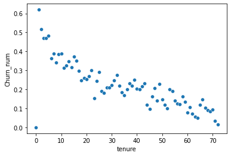

```python
import seaborn as sns

sns.scatterplot(data=te_ch, x='tenure', y='Churn_num')
```

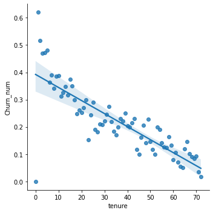

```python
sns.lmplot(data=te_ch, x='tenure', y='Churn_num')

# 계약기간이 길어질수록 이탈률이 낮아짐
```

```python
df.columns
```

```
Index(['customerID', 'gender', 'SeniorCitizen', 'Partner', 'Dependents',
       'tenure', 'PhoneService', 'MultipleLines', 'InternetService',
       'OnlineSecurity', 'OnlineBackup', 'DeviceProtection', 'TechSupport',
       'StreamingTV', 'StreamingMovies', 'Contract', 'PaperlessBilling',
       'PaymentMethod', 'MonthlyCharges', 'TotalCharges', 'Churn',
       'Churn_num'],
      dtype='object')
```

```python
hue = 'Dependents'
te_ch = df.groupby(['tenure', hue]).agg({'Churn_num': np.mean}).reset_index()
te_ch
```

|  | tenure | Dependents | Churn_num |
| --- | --- | --- | --- |
| 0 | 0 | Yes | 0.000000 |
| 1 | 1 | No | 0.632613 |
| 2 | 1 | Yes | 0.557692 |
| 3 | 2 | No | 0.538095 |
| 4 | 2 | Yes | 0.357143 |
| ... | ... | ... | ... |
| 140 | 70 | Yes | 0.063830 |
| 141 | 71 | No | 0.038095 |
| 142 | 71 | Yes | 0.030769 |
| 143 | 72 | No | 0.020000 |
| 144 | 72 | Yes | 0.012346 |

145 rows × 3 columns

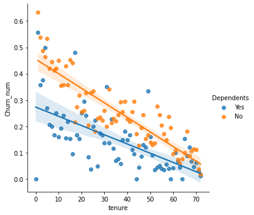

```python
sns.lmplot(data=te_ch, x='tenure', y='Churn_num', hue=hue)

# 계약기간이 길어짐에 따라 이탈률이 감소한다는 특징은 유지
# 부양가족이 있는 경우가 부양가족이 없는 경우보다 이탈률이 낮음
```

```python
# 다른 경우의 수 column들도 확인

df.describe(include='object')
```

|  | customerID | gender | Partner | Dependents | PhoneService | MultipleLines | InternetService | OnlineSecurity | OnlineBackup | DeviceProtection | TechSupport | StreamingTV | StreamingMovies | Contract | PaperlessBilling | PaymentMethod | Churn |
| --- | --- | --- | --- | --- | --- | --- | --- | --- | --- | --- | --- | --- | --- | --- | --- | --- | --- |
| count | 7043 | 7043 | 7043 | 7043 | 7043 | 7043 | 7043 | 7043 | 7043 | 7043 | 7043 | 7043 | 7043 | 7043 | 7043 | 7043 | 7043 |
| unique | 7043 | 2 | 2 | 2 | 2 | 3 | 3 | 3 | 3 | 3 | 3 | 3 | 3 | 3 | 2 | 4 | 2 |
| top | 7590-VHVEG | Male | No | No | Yes | No | Fiber optic | No | No | No | No | No | No | Month-to-month | Yes | Electronic check | No |
| freq | 1 | 3555 | 3641 | 4933 | 6361 | 3390 | 3096 | 3498 | 3088 | 3095 | 3473 | 2810 | 2785 | 3875 | 4171 | 2365 | 5174 |

```python
df.describe(include='object').columns
```

```
Index(['customerID', 'gender', 'Partner', 'Dependents', 'PhoneService',
       'MultipleLines', 'InternetService', 'OnlineSecurity', 'OnlineBackup',
       'DeviceProtection', 'TechSupport', 'StreamingTV', 'StreamingMovies',
       'Contract', 'PaperlessBilling', 'PaymentMethod', 'Churn'],
      dtype='object')
```

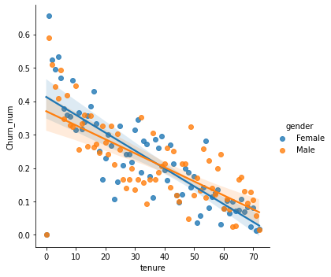

```python
hue = 'gender'
te_ch = df.groupby(['tenure', hue]).agg({'Churn_num': np.mean}).reset_index()
sns.lmplot(data=te_ch, x='tenure', y='Churn_num', hue=hue)

# 성별에 따른 차이가 없음
```

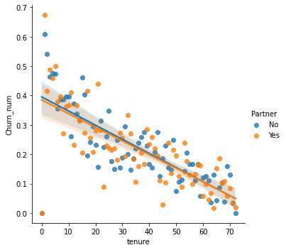

```python
hue = 'Partner'
te_ch = df.groupby(['tenure', hue]).agg({'Churn_num': np.mean}).reset_index()
sns.lmplot(data=te_ch, x='tenure', y='Churn_num', hue=hue)

# 동반자 여부에 따른 차이가 없음
```

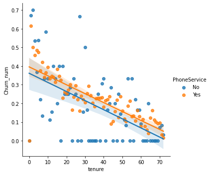

```python
hue = 'PhoneService'
te_ch = df.groupby(['tenure', hue]).agg({'Churn_num': np.mean}).reset_index()
sns.lmplot(data=te_ch, x='tenure', y='Churn_num', hue=hue)

# 전화서비스를 사용하지 않으면 이탈률이 전체적으로 낮아지는 경향이 있지만,
# 이탈률이 0%인 경우가 많고 편차도 큼
# 즉, 전화 사용여부에 따른 차이가 없음
```

```python
df.loc[df['tenure'] == 32]['PhoneService'].value_counts()
# 경우의 수가 적어서 전화 사용여부에 따른 차이가 발견되었다고 할 수 없음
```

```
Yes    65
No      4
Name: PhoneService, dtype: int64
```

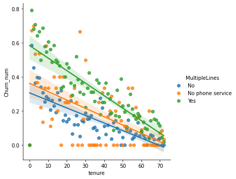

```python
hue = 'MultipleLines'
te_ch = df.groupby(['tenure', hue]).agg({'Churn_num': np.mean}).reset_index()
sns.lmplot(data=te_ch, x='tenure', y='Churn_num', hue=hue)

# 다중회선을 사용하면 이탈률이 높아지는 경향이 있음
```

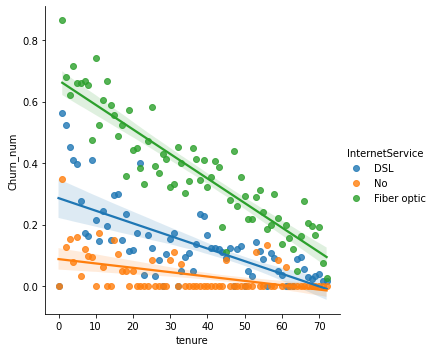

```python
hue = 'InternetService'
te_ch = df.groupby(['tenure', hue]).agg({'Churn_num': np.mean}).reset_index()
sns.lmplot(data=te_ch, x='tenure', y='Churn_num', hue=hue)

# 인터넷 속도가 증가할수록 이탈률이 높아짐
```

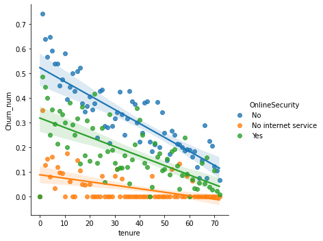

```python
hue = 'OnlineSecurity'
te_ch = df.groupby(['tenure', hue]).agg({'Churn_num': np.mean}).reset_index()
sns.lmplot(data=te_ch, x='tenure', y='Churn_num', hue=hue)

# 보안 서비스를 이용하면 이탈률이 낮아짐
```

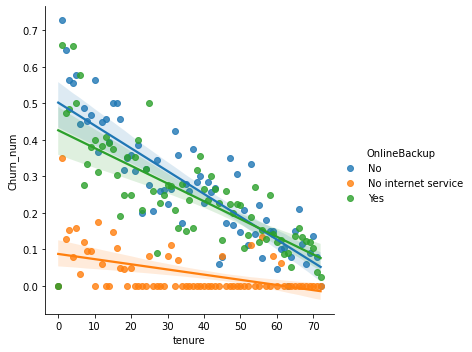

```python
hue = 'OnlineBackup'
te_ch = df.groupby(['tenure', hue]).agg({'Churn_num': np.mean}).reset_index()
sns.lmplot(data=te_ch, x='tenure', y='Churn_num', hue=hue)

# 백업 서비스 이용여부에 따른 이탈률의 차이가 없음
```

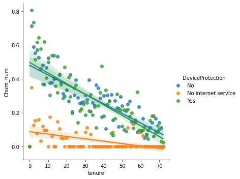

```python
hue = 'DeviceProtection'
te_ch = df.groupby(['tenure', hue]).agg({'Churn_num': np.mean}).reset_index()
sns.lmplot(data=te_ch, x='tenure', y='Churn_num', hue=hue)

# 기기 보호 서비스 이용여부에 따른 이탈률의 차이가 없음
```

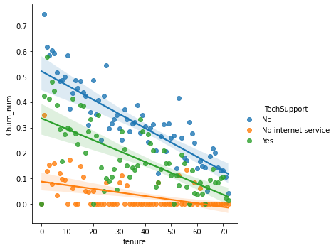

```python
hue = 'TechSupport'
te_ch = df.groupby(['tenure', hue]).agg({'Churn_num': np.mean}).reset_index()
sns.lmplot(data=te_ch, x='tenure', y='Churn_num', hue=hue)

# 기술 지원 서비스를 이용하면 이탈률이 낮아짐
```

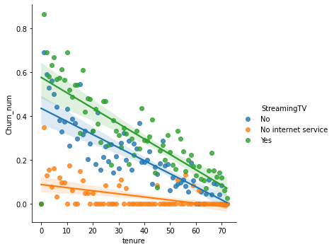

```python
hue = 'StreamingTV'
te_ch = df.groupby(['tenure', hue]).agg({'Churn_num': np.mean}).reset_index()
sns.lmplot(data=te_ch, x='tenure', y='Churn_num', hue=hue)

# 스트리밍 TV 서비스를 이용하면 이탈률이 높아짐
```

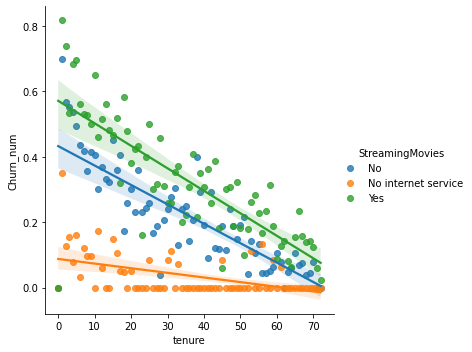

```python
hue = 'StreamingMovies'
te_ch = df.groupby(['tenure', hue]).agg({'Churn_num': np.mean}).reset_index()
sns.lmplot(data=te_ch, x='tenure', y='Churn_num', hue=hue)

# 스트리밍 영화 서비스를 이용하면 이탈률이 높아짐
```

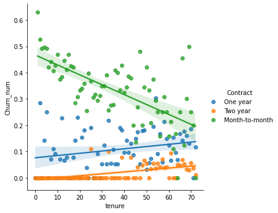

```python
hue = 'Contract'
te_ch = df.groupby(['tenure', hue]).agg({'Churn_num': np.mean}).reset_index()
sns.lmplot(data=te_ch, x='tenure', y='Churn_num', hue=hue)

# 계약기간이 늘어남에 따라 이탈률이 감소한다는 특징이 유지되지 않음
# 2년 계약의 경우에 tenure가 24까지는 0%, 그 이후에 취소함
# 1년 계약에서는 나타나지 않음
# 결제 갱신주기가 짧아질수록 이탈률이 높아지는 경향이 있음
```

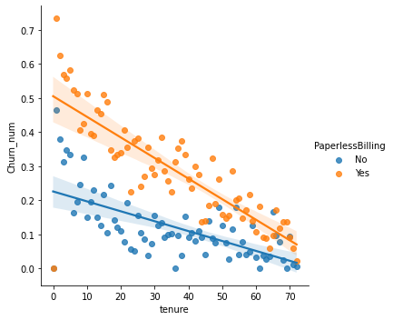

```python
hue = 'PaperlessBilling'
te_ch = df.groupby(['tenure', hue]).agg({'Churn_num': np.mean}).reset_index()
sns.lmplot(data=te_ch, x='tenure', y='Churn_num', hue=hue)

# 통지서가 paperless인 경우 이탈률이 높음
```

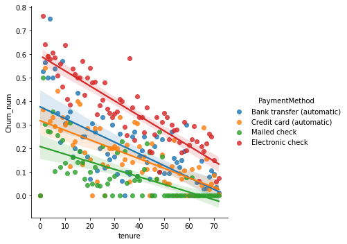

```python
hue = 'PaymentMethod'
te_ch = df.groupby(['tenure', hue]).agg({'Churn_num': np.mean}).reset_index()
sns.lmplot(data=te_ch, x='tenure', y='Churn_num', hue=hue)

# 지불 방식의 발전 순서대로 이탈률이 높아짐
```

#### 공통 특징

- 계약 기간이 늘어남에 따라 이탈률이 감소

#### 고객정보 기반

- 성별이나 동반자에 따른 차이가 없음
- 부양가족이 있으면 이탈률이 낮음

#### 서비스 기반

- 전화, 백업, 기기보호 서비스 이용여부에 따른 차이가 없음
- 인터넷 서비스, 다중회선, 스트리밍 TV, 영화 서비스를 사용하면 이탈률이 높아짐 -> 돈을 더 낼수록 이탈률 ↑
- 보안, 기술 서비스를 이용하면 이탈률이 낮아짐 --> 돈을 안 낼수록 이탈률 ↑

#### 계약 정보 기반

- 계약기간이 늘어남에 따라 이탈률이 감소한다는 특징이 유지되지 않음
- 2년 계약의 경우에 tenure가 24까지는 0%, 그 이후에 취소함
- 1년 계약에서는 나타나지 않음
- 결제 갱신주기가 짧아질수록 이탈률이 높아지는 경향이 있음
- 통지서가 paperless인 경우 이탈률이 높음
- 지불 방식의 발전 순서대로 이탈률이 높아짐

## Data Preparation

- 이상치 판별, 처리
- scaling
- 경우의 column 처리
- 교차검증

#### 이상치(Outlier)

- 기준을 정해서 기준선 밖에 있으면 이상치라 판단

#### 기준을 정하는 방법

- 평균에서 n표준편차 이상 떨어진 것을 이상치라 판단 -> 신뢰할 수 없음
- ex) 평균으로부터 엄청 크거나 작은 값이 있는데 이에 대한 경우의 수가 적으면 평균과 표준편차의 의미가 퇴색됨
- IQR(Inter Qurtile Range)
- MAD(Median Absolute Deviation)
- MCOD(Monte-Carlo Outlier Detection)

#### 식별된 이상치가 있는 경우 대처법

- 경우의 수가 적으면 지움
- 경계선의 값으로 대체(Winsorize)
- Business Understanding에서 설정한 방향성이 이상치 탐지인 경우 label로 둠

#### IQR

- Inter: a와 b 사이
- Quartile: 크기 순으로 정렬했을 때, 4분할 -> 순서상 25%, 75%
- Range: 범위

```python
df.describe()
```

|  | SeniorCitizen | tenure | MonthlyCharges | TotalCharges | Churn_num |
| --- | --- | --- | --- | --- | --- |
| count | 7043.000000 | 7043.000000 | 7043.000000 | 7043.000000 | 7043.000000 |
| mean | 0.162147 | 32.371149 | 64.761692 | 2279.734304 | 0.265370 |
| std | 0.368612 | 24.559481 | 30.090047 | 2266.794470 | 0.441561 |
| min | 0.000000 | 0.000000 | 18.250000 | 0.000000 | 0.000000 |
| 25% | 0.000000 | 9.000000 | 35.500000 | 398.550000 | 0.000000 |
| 50% | 0.000000 | 29.000000 | 70.350000 | 1394.550000 | 0.000000 |
| 75% | 0.000000 | 55.000000 | 89.850000 | 3786.600000 | 1.000000 |
| max | 1.000000 | 72.000000 | 118.750000 | 8684.800000 | 1.000000 |

```python
tgt_col = 'TotalCharges'
desc = df.describe()[tgt_col]

iqr = 1.5 * (desc['75%'] - desc['25%']) # 1.5 IQR
upper_lim = desc['75%'] + iqr
lower_lim = desc['25%'] - iqr
```

```python
df.loc[(df[tgt_col] > upper_lim) | (df[tgt_col] < lower_lim)]
```

|  | customerID | gender | SeniorCitizen | Partner | Dependents | tenure | PhoneService | MultipleLines | InternetService | OnlineSecurity | ... | TechSupport | StreamingTV | StreamingMovies | Contract | PaperlessBilling | PaymentMethod | MonthlyCharges | TotalCharges | Churn | Churn_num |
| --- | --- | --- | --- | --- | --- | --- | --- | --- | --- | --- | --- | --- | --- | --- | --- | --- | --- | --- | --- | --- | --- |

0 rows × 22 columns

```python
# 평균으로부처 표준편차 2.5에 해당하는 값들을 구하세요.
desc = df.describe()[tgt_col]

upper_lim = desc['mean'] + (2.5 * desc['std'])
lower_lim = desc['mean'] - (2.5 * desc['std'])
```

#### scaling

- 변수의 범위를 조정해주는 것
- 단위가 큰 column이 단위가 작은 column 에 비해 학습 단계에서 미치는 영향이 큰 경우 -> 이 영향을 최소화하기 위해 scaling 함
- 그래프 그릴 때
- 자릿수가 작아야 속도가 빠른 경우 ex) 이미지 DL

#### 종류

- min-max
- standard
- robust
- 이상치에 미치는 영향도: min-max > standard > robust

```python
# min-max
# a - a = 0
# a / a = 1
# 모든 값에 대해 최소값으로 빼고, 최대값으로 일괄 나누기

tgt_col = 'tenure'

minus_min = df[tgt_col] - np.min(df[tgt_col])
scaled = minus_min / np.max(minus_min)
scaled
```

```
0       0.013889
1       0.472222
2       0.027778
3       0.625000
4       0.027778
          ...
7038    0.333333
7039    1.000000
7040    0.152778
7041    0.055556
7042    0.916667
Name: tenure, Length: 7043, dtype: float64
```

```python
df[tgt_col + '_scal'] = scaled
df.describe()
```

|  | SeniorCitizen | tenure | MonthlyCharges | TotalCharges | Churn_num | tenure_scal |
| --- | --- | --- | --- | --- | --- | --- |
| count | 7043.000000 | 7043.000000 | 7043.000000 | 7043.000000 | 7043.000000 | 7043.000000 |
| mean | 0.162147 | 32.371149 | 64.761692 | 2279.734304 | 0.265370 | 0.449599 |
| std | 0.368612 | 24.559481 | 30.090047 | 2266.794470 | 0.441561 | 0.341104 |
| min | 0.000000 | 0.000000 | 18.250000 | 0.000000 | 0.000000 | 0.000000 |
| 25% | 0.000000 | 9.000000 | 35.500000 | 398.550000 | 0.000000 | 0.125000 |
| 50% | 0.000000 | 29.000000 | 70.350000 | 1394.550000 | 0.000000 | 0.402778 |
| 75% | 0.000000 | 55.000000 | 89.850000 | 3786.600000 | 1.000000 | 0.763889 |
| max | 1.000000 | 72.000000 | 118.750000 | 8684.800000 | 1.000000 | 1.000000 |

```python
# Q) MothlyCharges, TotalCharges도 min-max scaling 하세요.
scal_col = ['tenure', 'MonthlyCharges', 'TotalCharges']

for tgt_col in scal_col:
    minus_min = df[tgt_col] - np.min(df[tgt_col])
    df[tgt_col + '_mm_scal'] = minus_min / np.max(minus_min)
df.describe()
```

|  | SeniorCitizen | tenure | MonthlyCharges | TotalCharges | Churn_num | tenure_scal | tenure_mm_scal | MonthlyCharges_mm_scal | TotalCharges_mm_scal |
| --- | --- | --- | --- | --- | --- | --- | --- | --- | --- |
| count | 7043.000000 | 7043.000000 | 7043.000000 | 7043.000000 | 7043.000000 | 7043.000000 | 7043.000000 | 7043.000000 | 7043.000000 |
| mean | 0.162147 | 32.371149 | 64.761692 | 2279.734304 | 0.265370 | 0.449599 | 0.449599 | 0.462803 | 0.262497 |
| std | 0.368612 | 24.559481 | 30.090047 | 2266.794470 | 0.441561 | 0.341104 | 0.341104 | 0.299403 | 0.261007 |
| min | 0.000000 | 0.000000 | 18.250000 | 0.000000 | 0.000000 | 0.000000 | 0.000000 | 0.000000 | 0.000000 |
| 25% | 0.000000 | 9.000000 | 35.500000 | 398.550000 | 0.000000 | 0.125000 | 0.125000 | 0.171642 | 0.045891 |
| 50% | 0.000000 | 29.000000 | 70.350000 | 1394.550000 | 0.000000 | 0.402778 | 0.402778 | 0.518408 | 0.160574 |
| 75% | 0.000000 | 55.000000 | 89.850000 | 3786.600000 | 1.000000 | 0.763889 | 0.763889 | 0.712438 | 0.436003 |
| max | 1.000000 | 72.000000 | 118.750000 | 8684.800000 | 1.000000 | 1.000000 | 1.000000 | 1.000000 | 1.000000 |

```python
scal_col = ['tenure', 'MonthlyCharges', 'TotalCharges']

for tgt_col in scal_col:
    minus_min = df[tgt_col] - np.mean(df[tgt_col]) # 평균으로 빼기
    df[tgt_col + '_std_scal'] = minus_min / np.std(minus_min) # 표준편차로 나누기
df.describe()
```

|  | SeniorCitizen | tenure | MonthlyCharges | TotalCharges | Churn_num | tenure_scal | tenure_mm_scal | MonthlyCharges_mm_scal | TotalCharges_mm_scal | tenure_std_scal | MonthlyCharges_std_scal | TotalCharges_std_scal |
| --- | --- | --- | --- | --- | --- | --- | --- | --- | --- | --- | --- | --- |
| count | 7043.000000 | 7043.000000 | 7043.000000 | 7043.000000 | 7043.000000 | 7043.000000 | 7043.000000 | 7043.000000 | 7043.000000 | 7.043000e+03 | 7.043000e+03 | 7.043000e+03 |
| mean | 0.162147 | 32.371149 | 64.761692 | 2279.734304 | 0.265370 | 0.449599 | 0.449599 | 0.462803 | 0.262497 | -4.066982e-17 | -1.513422e-15 | -1.635494e-15 |
| std | 0.368612 | 24.559481 | 30.090047 | 2266.794470 | 0.441561 | 0.341104 | 0.341104 | 0.299403 | 0.261007 | 1.000071e+00 | 1.000071e+00 | 1.000071e+00 |
| min | 0.000000 | 0.000000 | 18.250000 | 0.000000 | 0.000000 | 0.000000 | 0.000000 | 0.000000 | 0.000000 | -1.318165e+00 | -1.545860e+00 | -1.005780e+00 |
| 25% | 0.000000 | 9.000000 | 35.500000 | 398.550000 | 0.000000 | 0.125000 | 0.125000 | 0.171642 | 0.045891 | -9.516817e-01 | -9.725399e-01 | -8.299464e-01 |
| 50% | 0.000000 | 29.000000 | 70.350000 | 1394.550000 | 0.000000 | 0.402778 | 0.402778 | 0.518408 | 0.160574 | -1.372744e-01 | 1.857327e-01 | -3.905282e-01 |
| 75% | 0.000000 | 55.000000 | 89.850000 | 3786.600000 | 1.000000 | 0.763889 | 0.763889 | 0.712438 | 0.436003 | 9.214551e-01 | 8.338335e-01 | 6.648034e-01 |
| max | 1.000000 | 72.000000 | 118.750000 | 8684.800000 | 1.000000 | 1.000000 | 1.000000 | 1.000000 | 1.000000 | 1.613701e+00 | 1.794352e+00 | 2.825806e+00 |

#### 경우의 column 변환과정

```python
df.head().T
```

|  | 0 | 1 | 2 | 3 | 4 |
| --- | --- | --- | --- | --- | --- |
| customerID | 7590-VHVEG | 5575-GNVDE | 3668-QPYBK | 7795-CFOCW | 9237-HQITU |
| gender | Female | Male | Male | Male | Female |
| SeniorCitizen | 0 | 0 | 0 | 0 | 0 |
| Partner | Yes | No | No | No | No |
| Dependents | No | No | No | No | No |
| tenure | 1 | 34 | 2 | 45 | 2 |
| PhoneService | No | Yes | Yes | No | Yes |
| MultipleLines | No phone service | No | No | No phone service | No |
| InternetService | DSL | DSL | DSL | DSL | Fiber optic |
| OnlineSecurity | No | Yes | Yes | Yes | No |
| OnlineBackup | Yes | No | Yes | No | No |
| DeviceProtection | No | Yes | No | Yes | No |
| TechSupport | No | No | No | Yes | No |
| StreamingTV | No | No | No | No | No |
| StreamingMovies | No | No | No | No | No |
| Contract | Month-to-month | One year | Month-to-month | One year | Month-to-month |
| PaperlessBilling | Yes | No | Yes | No | Yes |
| PaymentMethod | Electronic check | Mailed check | Mailed check | Bank transfer (automatic) | Electronic check |
| MonthlyCharges | 29.85 | 56.95 | 53.85 | 42.3 | 70.7 |
| TotalCharges | 29.85 | 1889.5 | 108.15 | 1840.75 | 151.65 |
| Churn | No | No | Yes | No | Yes |
| Churn_num | 0 | 0 | 1 | 0 | 1 |
| tenure_scal | 0.013889 | 0.472222 | 0.027778 | 0.625 | 0.027778 |
| tenure_mm_scal | 0.013889 | 0.472222 | 0.027778 | 0.625 | 0.027778 |
| MonthlyCharges_mm_scal | 0.115423 | 0.385075 | 0.354229 | 0.239303 | 0.521891 |
| TotalCharges_mm_scal | 0.003437 | 0.217564 | 0.012453 | 0.211951 | 0.017462 |
| tenure_std_scal | -1.277445 | 0.066327 | -1.236724 | 0.514251 | -1.236724 |
| MonthlyCharges_std_scal | -1.160323 | -0.259629 | -0.36266 | -0.746535 | 0.197365 |
| TotalCharges_std_scal | -0.992611 | -0.172165 | -0.958066 | -0.193672 | -0.938874 |

```python
yes_no_col = ['Partner', 'Dependents', 'PhoneService', 'PaperlessBilling']

for tgt in yes_no_col:
    mapper = {'No': 0, 'Yes': 1}
    df[tgt + '_num'] = df[tgt].map(mapper)

df.head()
```

|  | customerID | gender | SeniorCitizen | Partner | Dependents | tenure | PhoneService | MultipleLines | InternetService | OnlineSecurity | ... | tenure_mm_scal | MonthlyCharges_mm_scal | TotalCharges_mm_scal | tenure_std_scal | MonthlyCharges_std_scal | TotalCharges_std_scal | Partner_num | Dependents_num | PhoneService_num | PaperlessBilling_num |
| --- | --- | --- | --- | --- | --- | --- | --- | --- | --- | --- | --- | --- | --- | --- | --- | --- | --- | --- | --- | --- | --- |
| 0 | 7590-VHVEG | Female | 0 | Yes | No | 1 | No | No phone service | DSL | No | ... | 0.013889 | 0.115423 | 0.003437 | -1.277445 | -1.160323 | -0.992611 | 1 | 0 | 0 | 1 |
| 1 | 5575-GNVDE | Male | 0 | No | No | 34 | Yes | No | DSL | Yes | ... | 0.472222 | 0.385075 | 0.217564 | 0.066327 | -0.259629 | -0.172165 | 0 | 0 | 1 | 0 |
| 2 | 3668-QPYBK | Male | 0 | No | No | 2 | Yes | No | DSL | Yes | ... | 0.027778 | 0.354229 | 0.012453 | -1.236724 | -0.362660 | -0.958066 | 0 | 0 | 1 | 1 |
| 3 | 7795-CFOCW | Male | 0 | No | No | 45 | No | No phone service | DSL | Yes | ... | 0.625000 | 0.239303 | 0.211951 | 0.514251 | -0.746535 | -0.193672 | 0 | 0 | 0 | 0 |
| 4 | 9237-HQITU | Female | 0 | No | No | 2 | Yes | No | Fiber optic | No | ... | 0.027778 | 0.521891 | 0.017462 | -1.236724 | 0.197365 | -0.938874 | 0 | 0 | 1 | 1 |

5 rows × 33 columns

```python
set(df['InternetService'])
```

```
{'DSL', 'Fiber optic', 'No'}
```

```python
mapper = {'No': 0, 'DSL': 0.5, 'Fiber optic': 1}
df['InternetSpeed'] = df['InternetService'].map(mapper)
df.describe()
```

|  | SeniorCitizen | tenure | MonthlyCharges | TotalCharges | Churn_num | tenure_scal | tenure_mm_scal | MonthlyCharges_mm_scal | TotalCharges_mm_scal | tenure_std_scal | MonthlyCharges_std_scal | TotalCharges_std_scal | Partner_num | Dependents_num | PhoneService_num | PaperlessBilling_num | InternetSpeed |
| --- | --- | --- | --- | --- | --- | --- | --- | --- | --- | --- | --- | --- | --- | --- | --- | --- | --- |
| count | 7043.000000 | 7043.000000 | 7043.000000 | 7043.000000 | 7043.000000 | 7043.000000 | 7043.000000 | 7043.000000 | 7043.000000 | 7.043000e+03 | 7.043000e+03 | 7.043000e+03 | 7043.000000 | 7043.000000 | 7043.000000 | 7043.000000 | 7043.000000 |
| mean | 0.162147 | 32.371149 | 64.761692 | 2279.734304 | 0.265370 | 0.449599 | 0.449599 | 0.462803 | 0.262497 | -4.066982e-17 | -1.513422e-15 | -1.635494e-15 | 0.483033 | 0.299588 | 0.903166 | 0.592219 | 0.611458 |
| std | 0.368612 | 24.559481 | 30.090047 | 2266.794470 | 0.441561 | 0.341104 | 0.341104 | 0.299403 | 0.261007 | 1.000071e+00 | 1.000071e+00 | 1.000071e+00 | 0.499748 | 0.458110 | 0.295752 | 0.491457 | 0.389438 |
| min | 0.000000 | 0.000000 | 18.250000 | 0.000000 | 0.000000 | 0.000000 | 0.000000 | 0.000000 | 0.000000 | -1.318165e+00 | -1.545860e+00 | -1.005780e+00 | 0.000000 | 0.000000 | 0.000000 | 0.000000 | 0.000000 |
| 25% | 0.000000 | 9.000000 | 35.500000 | 398.550000 | 0.000000 | 0.125000 | 0.125000 | 0.171642 | 0.045891 | -9.516817e-01 | -9.725399e-01 | -8.299464e-01 | 0.000000 | 0.000000 | 1.000000 | 0.000000 | 0.500000 |
| 50% | 0.000000 | 29.000000 | 70.350000 | 1394.550000 | 0.000000 | 0.402778 | 0.402778 | 0.518408 | 0.160574 | -1.372744e-01 | 1.857327e-01 | -3.905282e-01 | 0.000000 | 0.000000 | 1.000000 | 1.000000 | 0.500000 |
| 75% | 0.000000 | 55.000000 | 89.850000 | 3786.600000 | 1.000000 | 0.763889 | 0.763889 | 0.712438 | 0.436003 | 9.214551e-01 | 8.338335e-01 | 6.648034e-01 | 1.000000 | 1.000000 | 1.000000 | 1.000000 | 1.000000 |
| max | 1.000000 | 72.000000 | 118.750000 | 8684.800000 | 1.000000 | 1.000000 | 1.000000 | 1.000000 | 1.000000 | 1.613701e+00 | 1.794352e+00 | 2.825806e+00 | 1.000000 | 1.000000 | 1.000000 | 1.000000 | 1.000000 |

```python
df.describe().columns
```

```
Index(['SeniorCitizen', 'tenure', 'MonthlyCharges', 'TotalCharges',
       'Churn_num', 'tenure_scal', 'tenure_mm_scal', 'MonthlyCharges_mm_scal',
       'TotalCharges_mm_scal', 'tenure_std_scal', 'MonthlyCharges_std_scal',
       'TotalCharges_std_scal', 'Partner_num', 'Dependents_num',
       'PhoneService_num', 'PaperlessBilling_num', 'InternetSpeed'],
      dtype='object')
```

```python
interested = ['SeniorCitizen', 'Churn_num', 'tenure_mm_scal', 'MonthlyCharges_mm_scal',
       'TotalCharges_mm_scal', 'Partner_num', 'Dependents_num',
       'PhoneService_num', 'PaperlessBilling_num', 'InternetSpeed']

df[interested].to_csv('test3_modify.csv', index=False)
```

```python
df = pd.read_csv('test3_modify.csv')
df.columns
```

```
Index(['SeniorCitizen', 'Churn_num', 'tenure_mm_scal',
       'MonthlyCharges_mm_scal', 'TotalCharges_mm_scal', 'Partner_num',
       'Dependents_num', 'PhoneService_num', 'PaperlessBilling_num',
       'InternetSpeed'],
      dtype='object')
```

```python
label = 'Churn_num'
features = ['SeniorCitizen', 'tenure_mm_scal', 'MonthlyCharges_mm_scal',
            'TotalCharges_mm_scal', 'Partner_num', 'Dependents_num',
            'PhoneService_num', 'PaperlessBilling_num', 'InternetSpeed']

X, y = df[features], df[label]
```

## Modeling

- 교차 검증

#### Cross Validation 순서

1. row 순서를 섞음
2. 데이터셋을 k등분함(k-fold CV)
3. 첫 번째 데이터셋을 test, 나머지를 train
4. train로 학습하고, test 채점해서 점수 확인
5. 두 번째 데이터셋을 test, 나머지를 train -> 3, 4 단계를 k번 반복
6. 평가지표 점수가 k개 생김
7. 평균(CV-score)

```python
from sklearn.model_selection import cross_val_score as cvs
from sklearn.ensemble import RandomForestClassifier as rf

model = rf()
cvs(model, X, y, cv=5, scoring='precision')
```

```
array([0.58709677, 0.60677966, 0.58208955, 0.60824742, 0.60855263])
```

```python
np.mean(cvs(model, X, y, cv=5, scoring='precision'))

# CV-score
```

```
0.5989742681107059
```

## supervised learning

- 정답이 있는 데이터로 학습하는 방식
- feature와 label 관계 패턴을 학습
- classfication, regression

## unsupervised learning

- 정답이 없는 데이터로 학습하는 방식
- feature간 관계 패턴을 학습
- 비지도 학습의 알고리즘들은 목적이 정해져 있음
- clustering, dimensionality reduction

## 군집 알고리즘

```python
from sklearn.cluster import KMeans

model = KMeans(n_clusters=4)
model.fit(X)
```

```
KMeans(n_clusters=4)
```

```python
model.labels_
```

```
array([1, 3, 2, ..., 0, 1, 2])
```

```python
df['cluster'] = model.labels_
```

```python
df.head()
```

|  | SeniorCitizen | Churn_num | tenure_mm_scal | MonthlyCharges_mm_scal | TotalCharges_mm_scal | Partner_num | Dependents_num | PhoneService_num | PaperlessBilling_num | InternetSpeed | cluster |
| --- | --- | --- | --- | --- | --- | --- | --- | --- | --- | --- | --- |
| 0 | 0 | 0 | 0.013889 | 0.115423 | 0.003437 | 1 | 0 | 0 | 1 | 0.5 | 1 |
| 1 | 0 | 0 | 0.472222 | 0.385075 | 0.217564 | 0 | 0 | 1 | 0 | 0.5 | 3 |
| 2 | 0 | 1 | 0.027778 | 0.354229 | 0.012453 | 0 | 0 | 1 | 1 | 0.5 | 2 |
| 3 | 0 | 0 | 0.625000 | 0.239303 | 0.211951 | 0 | 0 | 0 | 0 | 0.5 | 3 |
| 4 | 0 | 1 | 0.027778 | 0.521891 | 0.017462 | 0 | 0 | 1 | 1 | 1.0 | 2 |

```python
df.groupby('cluster').agg({label: np.mean})
```

| cluster | Churn_num |
| --- | --- |
| 0 | 0.138631 |
| 1 | 0.278201 |
| 2 | 0.412090 |
| 3 | 0.196251 |

```python
np.mean(df[label])
```

```
0.2653698707936959
```

```python
# 이탈률이 가장 낮은 그룹의 특징 확인

for_plot = df.loc[df['cluster'] == 0][features].describe().T['mean'].reset_index()
for_plot

# 고객들 선별하여 feature 들의 평균을 구함
# 그룹의 특징이라고 하고, cluster_mean이라 함
```

|  | index | mean |
| --- | --- | --- |
| 0 | SeniorCitizen | 0.023202 |
| 1 | tenure_mm_scal | 0.572868 |
| 2 | MonthlyCharges_mm_scal | 0.413951 |
| 3 | TotalCharges_mm_scal | 0.307497 |
| 4 | Partner_num | 0.989559 |
| 5 | Dependents_num | 1.000000 |
| 6 | PhoneService_num | 0.906032 |
| 7 | PaperlessBilling_num | 0.501160 |
| 8 | InternetSpeed | 0.497390 |

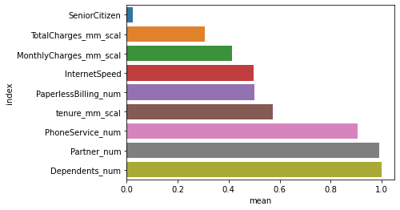

```python
import seaborn as sns

sns.barplot(data=for_plot.sort_values(by='mean'), x='mean', y='index')

# 평균 대비 이탈률이 낮은 그룹의 특징
# ?
```

## 차원 축소

- 주성분분석(PCA: principal component analysis)
- feature의 개수를 줄이는 것이지만 feature selection과는 다름
- 차원 축소를 하면 feature가 더이상 feature의 의미를 갖지 않음
- ex) 식당에서 식재료를 column이라 생각했을 때 PCA: 식재료가 100개 있고, 음식을 만들 때 식재료를 얼마나 썼는가를 DF이라고 가정. 주문 한 번 받은 것을 row, 사용된 식재료 사용량을 column이라 한다면? 전체 주문의 90%가 bestseller 2개라면 식재료 100개 아니라 메뉴 2개만으로도 90% 수준의 주문데이터를 설명할 수 있음. 100개 column -> 2개의 column

```python
from sklearn.decomposition import PCA

model = PCA(n_components=2)
pd.DataFrame(model.fit_transform(df[features]), columns=['PC1', 'PC2'])
```

|  | PC1 | PC2 |
| --- | --- | --- |
| 0 | 0.040610 | -0.075846 |
| 1 | -0.024132 | -0.667758 |
| 2 | -0.532593 | -0.487201 |
| 3 | 0.065065 | -0.733403 |
| 4 | -0.763095 | -0.243390 |
| ... | ... | ... |
| 7038 | 0.446972 | 0.584836 |
| 7039 | 0.287162 | 1.234141 |
| 7040 | 0.593813 | 0.220111 |
| 7041 | -0.497296 | 0.479294 |
| 7042 | -0.746942 | 0.393881 |

7043 rows × 2 columns

```python
pd.DataFrame(model.components_, columns=features)

# PC1 = (-0.212050*SeniorCitizen) + (0.132393*tenure_mm_scal) + ...
# PC2 =
```

|  | SeniorCitizen | tenure_mm_scal | MonthlyCharges_mm_scal | TotalCharges_mm_scal | Partner_num | Dependents_num | PhoneService_num | PaperlessBilling_num | InternetSpeed |
| --- | --- | --- | --- | --- | --- | --- | --- | --- | --- |
| 0 | -0.212050 | 0.132393 | -0.241975 | -0.022553 | 0.483483 | 0.535035 | -0.033571 | -0.461709 | -0.379639 |
| 1 | 0.134013 | 0.312694 | 0.340626 | 0.312551 | 0.561869 | 0.241981 | 0.062010 | 0.394147 | 0.370271 |

#### PCA 수학적 설명

- column끼리 공분산 구해서 공분산 행렬을 구함: .cov()
- 고유값, 고유벡터를 정방행렬에서 뽑아낼 수 있음
- 고유값의 크기 순으로 정렬할 수 있음
- 크기가 가장 큰 고유값부터 정렬하면 순서를 갖음
- 고유값과 고유벡터는 한 쌍으로 있음
- 고유벡터 크기가 큰 것부터 작은 것 순서대로 PC1, PC2, ... 으로 이름을 붙임